## Total inversions (NHCategory)

### Model fitting

```
## Call:
## polr(formula = myFormula, data = winRegions, Hess = T)
##
## Coefficients:
##                          Value Std. Error  t value
## Length.Mb.Scaled       1.82483     0.4175  4.37095
## allRepCounts.Scaled   -0.19475     0.2641 -0.73747
## Colorcentromeric       0.59203     0.8979  0.65932
## Colortelomeric         0.14965     0.6839  0.21882
## WAvgRate.perMb.Scaled -0.01151     0.4382 -0.02626
##
## Intercepts:
##      Value   Std. Error t value
## 0|1   0.5062  0.4906     1.0319
## 1|2   2.6307  0.5808     4.5290
## 2|3+  3.8728  0.6967     5.5590
##
## Residual Deviance: 172.2763
## AIC: 188.2763
```

We compare the t-value against the standard normal distribution to calculate the p-value.

```
##                             Value Std. Error     t value    p value
## Length.Mb.Scaled       1.82482830  0.4174902  4.37094864 0.00001237
## allRepCounts.Scaled   -0.19475006  0.2640801 -0.73746579 0.46083914
## Colorcentromeric       0.59202688  0.8979415  0.65931568 0.50969308
## Colortelomeric         0.14965463  0.6839101  0.21882209 0.82678864
## WAvgRate.perMb.Scaled -0.01150714  0.4381724 -0.02626168 0.97904862
## 0|1                    0.50620907  0.4905645  1.03189094 0.30212321
## 1|2                    2.63066232  0.5808437  4.52903687 0.00000593
## 2|3+                   3.87283588  0.6966735  5.55903968 0.00000003
```

We can also get confidence intervals for the parameter estimates. These can be obtained either by profiling the likelihood function or by using the standard errors and assuming a normal distribution. Note that profiled CIs are not symmetric (although they are usually close to symmetric). If the 95% CI does not cross 0, the parameter estimate is statistically significant.

```
## [1] "Profiling likelihod"
```

```
##                            2.5 %    97.5 %
## Length.Mb.Scaled       1.0634206 2.7085998
## allRepCounts.Scaled   -0.7474781 0.2977162
## Colorcentromeric      -1.0988549 2.4425947
## Colortelomeric        -1.1555540 1.5476395
## WAvgRate.perMb.Scaled -0.9034309 0.8205340
```

```
## [1] "Assuming a normal distribtuion"
```

```
##                            2.5 %    97.5 %
## Length.Mb.Scaled       1.0065625 2.6430941
## allRepCounts.Scaled   -0.7123376 0.3228375
## Colorcentromeric      -1.1679060 2.3519598
## Colortelomeric        -1.1907845 1.4900938
## WAvgRate.perMb.Scaled -0.8703093 0.8472950
```

We convert the coefficients into odds ratios. To get the OR and confidence intervals, we just exponentiate the estimates and confidence intervals (here I used the likelihood confidence intervals).

```
##                       Odds Ratio      2.5%     97.5%
## Length.Mb.Scaled       6.2017301 2.8962611 15.008247
## allRepCounts.Scaled    0.8230403 0.4735593  1.346780
## Colorcentromeric       1.8076486 0.3332525 11.502848
## Colortelomeric         1.1614331 0.3148830  4.700362
## WAvgRate.perMb.Scaled  0.9885588 0.4051771  2.271713
```

Example of interpretation: “For 1 unit increase in Length.Mb.Scaled, a window is 6.2017301 times more likely to increase in inversion amount category.”

### Proportional odds assessment

Now we should test the proportional odds or parallel regression assumption. If it is satisfied, the coefficients are valid for all the cases (i.e. the same coefficient is valid for increasing from 0 to 1 inversions, from 1 to 2, etc.). If this assumption is violated, different models are needed to describe the relationship between each pair of outcome groups.

We test the parallel regression assumption with a Brant test:

```
## ----------------------------------------------------
## Test for     X2  df  probability
## ----------------------------------------------------
## Omnibus          7.42    10  0.69
## Length.Mb.Scaled 5.91    2   0.05
## allRepCounts.Scaled  0.51    2   0.78
## Colorcentromeric 3.31    2   0.19
## Colortelomeric       0.02    2   0.99
## WAvgRate.perMb.Scaled    7.3 2   0.03
## ----------------------------------------------------
##
## H0: Parallel Regression Assumption holds
```

We can also evaluate the parallel regression visually. We transform the ordinal dependent variable with k categories into a series of k-1 binary variables that indicate whether the dependent value is above or below a cutpoint (e.g. windows with at least 2 inversions vs windows with less than 2 inversions). We then calculate the observed Log Odds Ratio for each binary variable across multiple value ranges of the independent variables. The lines should be approximately parallel, that each independent variable affects the probability of increasing by 1 level the inversion count in the same way, for all transitions, and that we don’t need a specific model for each level increase.

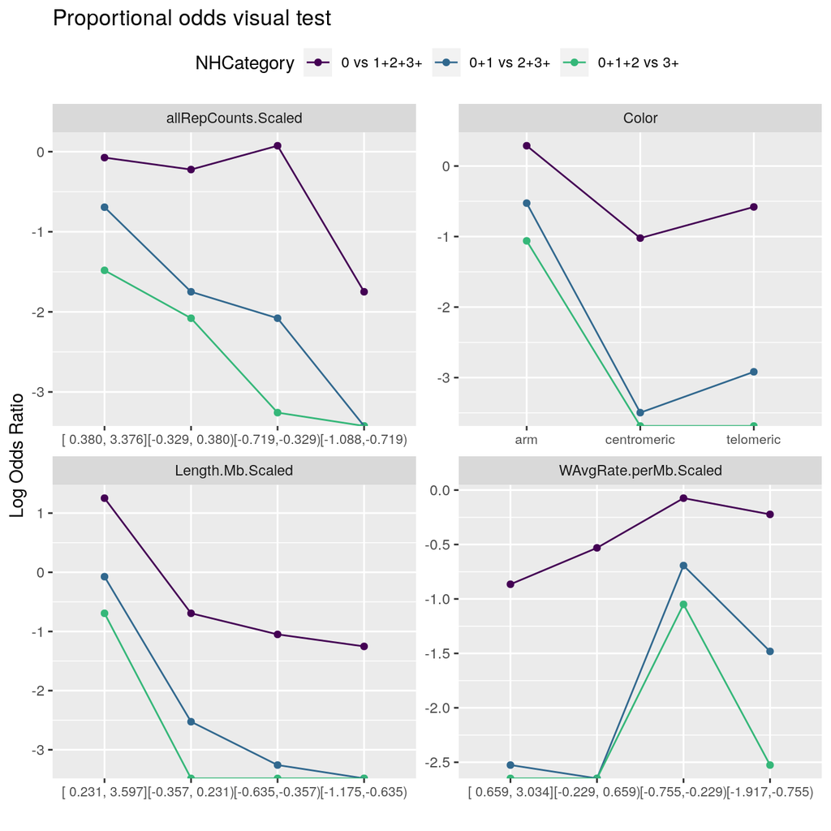

Binary logistic regressions with varying cutpoints on the dependent variable.

### Predicted probabilites

Although our objective is to describe the dataset, predicted probabilities are usually easier to understand than either the coefficients or the Odds Ratios.

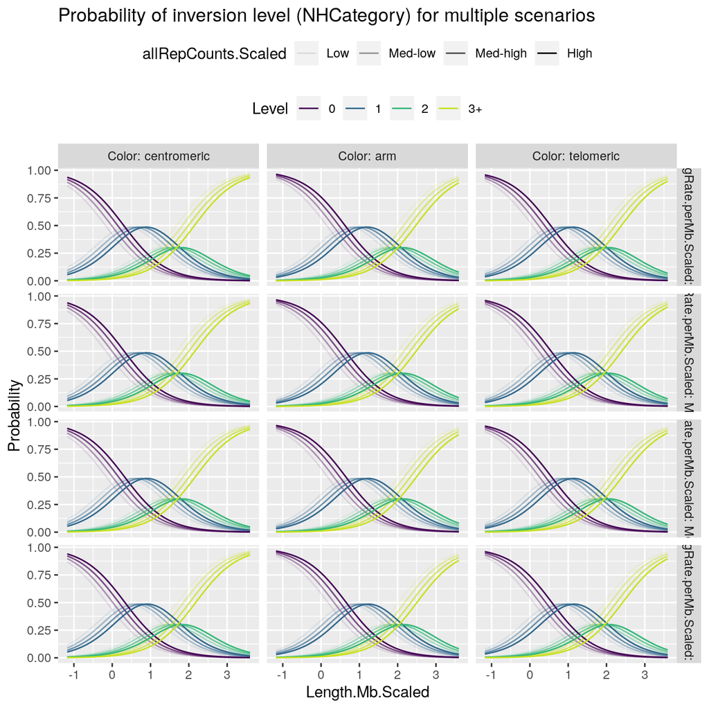

Probabiilty of having 0 to >3 inversions depending on multiple independent variables